# Network Analysis for the dataset1(first_10000.csv)

2024-04-21

```r
library(visNetwork)
```

```r
library(igraph)
library(ggplot2)
library(knitr)
```

```r
# Specify column classes for transactions dataset including token address and transaction hash
transactions_col_types <- c(
  transaction_hash = "character",
  from_address = "character",
  to_address = "character",
  token_address = "character",
  value = "numeric",
  timestamp = "integer"
)

# Specify column classes for label datasets
labels_col_types <- c(label = "character", address = "character",
                      name = "character", asset = "character")

# Read the datasets with explicit data type handling
transactions <- read.csv("C:/Users/zhouyi/Desktop/new/first_10000.csv",
                         colClasses = transactions_col_types, stringsAsFactors = FALSE)
alphacore_labels <- read.csv("C:/Users/zhouyi/Desktop/new/alphacore_labels_stablecoin.csv",
                             colClasses = labels_col_types, stringsAsFactors = FALSE)
exchange_labels <- read.csv("C:/Users/zhouyi/Desktop/new/exchangeLabels.csv",
                            colClasses = labels_col_types, stringsAsFactors = FALSE)
```

```r
# Creating the network
# Create an edge list from the transaction data
edge_list <- data.frame(from = transactions$from_address, to = transactions$to_address)

# Create a graph from the edge list
network <- graph_from_data_frame(edge_list, directed = TRUE)
```

1. Network Structure Analysis In this part, I calculate key structural properties of the Ethereum transaction network, such as its size, connectivity, and clustering. I also analyze its algebraic properties through the Laplacian matrix to assess network robustness and identify significant nodes. The outputs I generate include network metrics, a visual representation, and the eigenvalue spectrum.

```r
# Compute basic structural properties of the network
num_nodes <- vcount(network)
num_edges <- ecount(network)
node_degrees <- degree(network)
min_degree <- min(node_degrees)
max_degree <- max(node_degrees)
average_path_length <- average.path.length(network, directed = TRUE)
diameter_of_network <- diameter(network, directed = TRUE, unconnected = TRUE)
clustering_coefficient_global <- transitivity(network, type = "global")
g.density <- graph.density(network)

# Compute the Laplacian matrix and its eigenvalues
laplacian_matrix <- laplacian_matrix(network)
eigenvalues <- eigen(laplacian_matrix, symmetric = TRUE)$values
lambda2 <- eigenvalues[2]  # Second smallest eigenvalue
lambdan <- tail(eigenvalues, n=1)  # Largest eigenvalue

# Print the computed values
cat(sprintf("Number of Nodes: %d\n", num_nodes))
```

```
## Number of Nodes: 3974
```

```r
cat(sprintf("Number of Edges: %d\n", num_edges))
```

```
## Number of Edges: 10000
```

```r
cat(sprintf("Minimum Degree: %d\n", min_degree))
```

```
## Minimum Degree: 1
```

```r
cat(sprintf("Maximum Degree: %d\n", max_degree))
```

```
## Maximum Degree: 2742
```

```r
cat(sprintf("Average Path Length: %.4f\n", average_path_length))
```

```
## Average Path Length: 5.3551
```

```r
cat(sprintf("Diameter: %d\n", diameter_of_network))
```

```
## Diameter: 18
```

```r
cat(sprintf("Global Clustering Coefficient: %.4f\n", clustering_coefficient_global))
```

```
## Global Clustering Coefficient: 0.0019
```

```r
cat(sprintf("Algebraic Connectivity (λ2): %.4f\n", lambda2))
```

```
## Algebraic Connectivity (λ2): 518.8491
```

```r
cat(sprintf("Largest Eigenvalue (λn): %.4f\n", lambdan))
```

```
## Largest Eigenvalue (λn): -6.8936
```

```r
cat(sprintf("Density: %.4f\n", g.density), "\n")
```

```
## Density: 0.0006
##
```

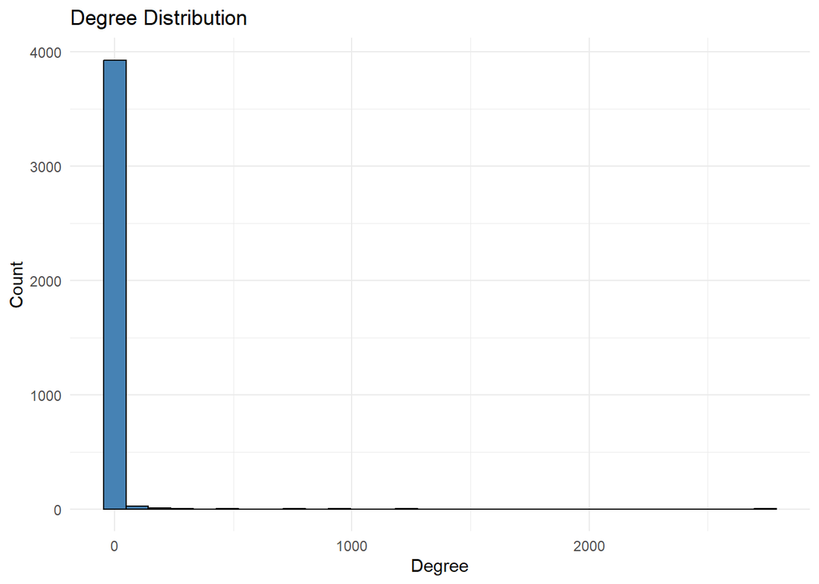

```r
# Visualizations
# Degree Distribution
degree_distribution <- data.frame(Degree = node_degrees)
ggplot(degree_distribution, aes(x = Degree)) +
  geom_histogram(bins = 30, fill = "steelblue", color = "black") +
  theme_minimal() +
  labs(title = "Degree Distribution", x = "Degree", y = "Count")
```

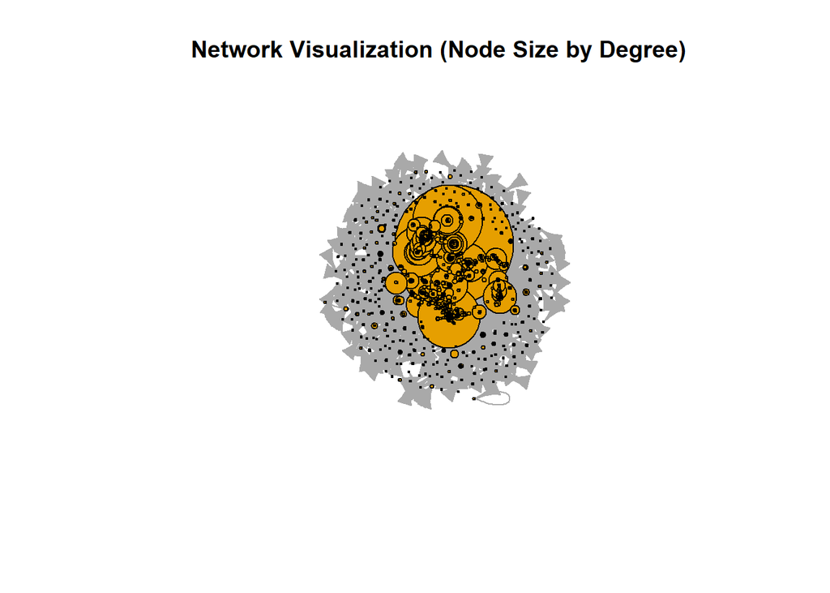

```r
# Network Visualization with Node Size Based on Degree
plot(network, vertex.size = sqrt(node_degrees) * 2, vertex.label = NA,
     main = "Network Visualization (Node Size by Degree)")
```

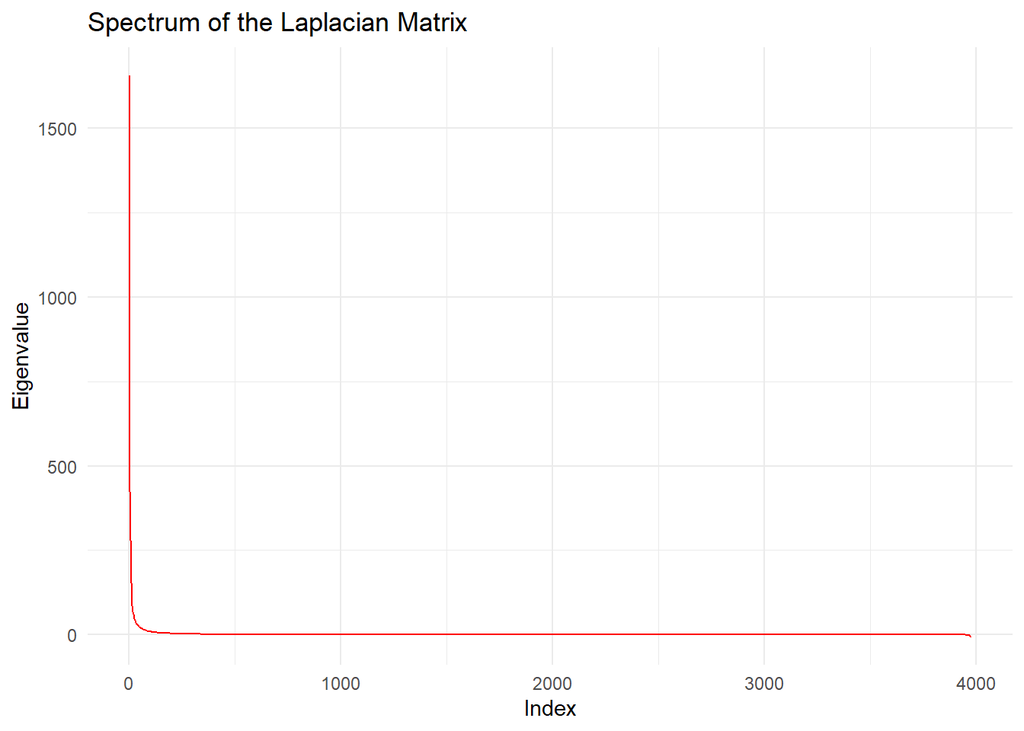

```r
# Eigenvector Spectrum of the Laplacian Matrix
eigenvalues_df <- data.frame(EigenvalueIndex = 1:length(eigenvalues), Eigenvalue = eigenvalues)
ggplot(eigenvalues_df, aes(x = EigenvalueIndex, y = Eigenvalue)) +
  geom_line(group = 1, color = "red") +
  theme_minimal() +
  labs(title = "Spectrum of the Laplacian Matrix", x = "Index", y = "Eigenvalue")
```

2.Node Importance Analysis In this part, I calculate various centrality measures of the Ethereum transaction network, identifying key nodes based on their structural importance. I analyze degree, closeness, betweenness, PageRank, and other centrality metrics, extracting the top five nodes for each and displaying them in a data frame. This allows me to understand network by highlighting the most influential nodes. Additionally, I convert these metrics into histograms, visually representing the distribution of centrality values.

```r
# Calculate various centrality measures
degree_centrality <- degree(network, mode = "all")
eccentricity_centrality <- eccentricity(network, mode = "all")
closeness_centrality <- closeness(network, normalized = TRUE)
betweenness_centrality <- betweenness(network, normalized = TRUE)
pagerank_centrality <- page_rank(network)$vector
authority_scores <- authority_score(network)$vector
hub_scores <- hub_score(network)$vector
eigenvector_centrality <- eigen_centrality(network)$vector

# Calculate top nodes for each centrality measure
centrality_measures <- list(
  "Degree" = degree_centrality,
  "Eccentricity" = eccentricity_centrality,
  "Closeness" = closeness_centrality,
  "Betweenness" = betweenness_centrality,
  "PageRank" = pagerank_centrality,
  "Authority" = authority_scores,
  "Hub" = hub_scores,
  "Eigenvector" = eigenvector_centrality
)

# Extract the top 5 nodes for each centrality measure and store them in a matrix for easy display
top_nodes_matrix <- sapply(centrality_measures, function(x) names(sort(x, decreasing = TRUE)[1:5]), simplify = TRUE)

# Convert the matrix to a data frame for nicer output
top_nodes_df <- as.data.frame(top_nodes_matrix)
colnames(top_nodes_df) <- names(centrality_measures)

# Print the heading and the data frame
cat("Top nodes by Centrality Measures:\n")
```

```
## Top nodes by Centrality Measures:
```

```r
print(top_nodes_df, row.names = FALSE)
```

```
##                                      Degree
##  0xf20b9e713a33f61fa38792d2afaf1cd30339126a
##  0x1f573d6fb3f13d689ff844b4ce37794d79a7ff1c
##  0xe269e891a2ec8585a378882ffa531141205e92e9
##  0x3f5ce5fbfe3e9af3971dd833d26ba9b5c936f0be
##  0x14fbca95be7e99c15cc2996c6c9d841e54b79425
##                                Eccentricity
##  0xb5d6c0ca5529b6e0a7f327cbed8276cabc370cd8
##  0xf4ef3725ff567453d8652a1ea207608fbdb9de8b
##  0x3123445c21406accfff5dc75734bf6921c835899
##  0x4d75ae527fb35cf675b345c21fcb81dbec80fae9
##  0x31037b6edbeb9f25c95d3887e7158c9b6e32eacc
##                                   Closeness
##  0x63c5608caea858240d661d9bfc811c62838cdf15
##  0xcf7c40d3ed4a13462387a281f61897cf1e193cc5
##  0x41d3deae4e9cab7de5755992e957f6e775d773ea
##  0xf73c3c65bde10bf26c2e1763104e609a41702efe
##  0xca7232d094e28f230955fcadc3ac39eb932cf47b
##                                 Betweenness
##  0x3f5ce5fbfe3e9af3971dd833d26ba9b5c936f0be
##  0x0681d8db095565fe8a346fa0277bffde9c0edbbf
##  0xd551234ae421e3bcba99a0da6d736074f22192ff
##  0x564286362092d8e7936f0549571a803b203aaced
##  0xf20b9e713a33f61fa38792d2afaf1cd30339126a
##                                    PageRank
##  0x3f5ce5fbfe3e9af3971dd833d26ba9b5c936f0be
##  0xf20b9e713a33f61fa38792d2afaf1cd30339126a
##  0xe269e891a2ec8585a378882ffa531141205e92e9
##  0x14fbca95be7e99c15cc2996c6c9d841e54b79425
##  0x1f573d6fb3f13d689ff844b4ce37794d79a7ff1c
##                                   Authority
##  0xf20b9e713a33f61fa38792d2afaf1cd30339126a
##  0x0016bd4cb70bd98ca07a341da66450b5d22a55aa
##  0x91a502c678605fbce581eae053319747482276b9
##  0x6924a03bb710eaf199ab6ac9f2bb148215ae9b5d
##  0xcf169a4dbad76e48963e71df79a5b4e46449695c
##                                         Hub
##  0x1f573d6fb3f13d689ff844b4ce37794d79a7ff1c
##  0x51907923c3280c24b6b69b0d217ea34cabde684d
##  0x599485dc0f3d8b308b973b2db5cd44bae46d31c4
##  0xfdbb3b3cfd6fcc0dd5c1b5bff05bffac1db42258
##  0x46ffcdc6d8e6ed69f124d944bbfe0ac74f8fcf7f
##                                 Eigenvector
##  0xf20b9e713a33f61fa38792d2afaf1cd30339126a
##  0x1f573d6fb3f13d689ff844b4ce37794d79a7ff1c
##  0x599485dc0f3d8b308b973b2db5cd44bae46d31c4
##  0x51907923c3280c24b6b69b0d217ea34cabde684d
##  0xfdbb3b3cfd6fcc0dd5c1b5bff05bffac1db42258
```

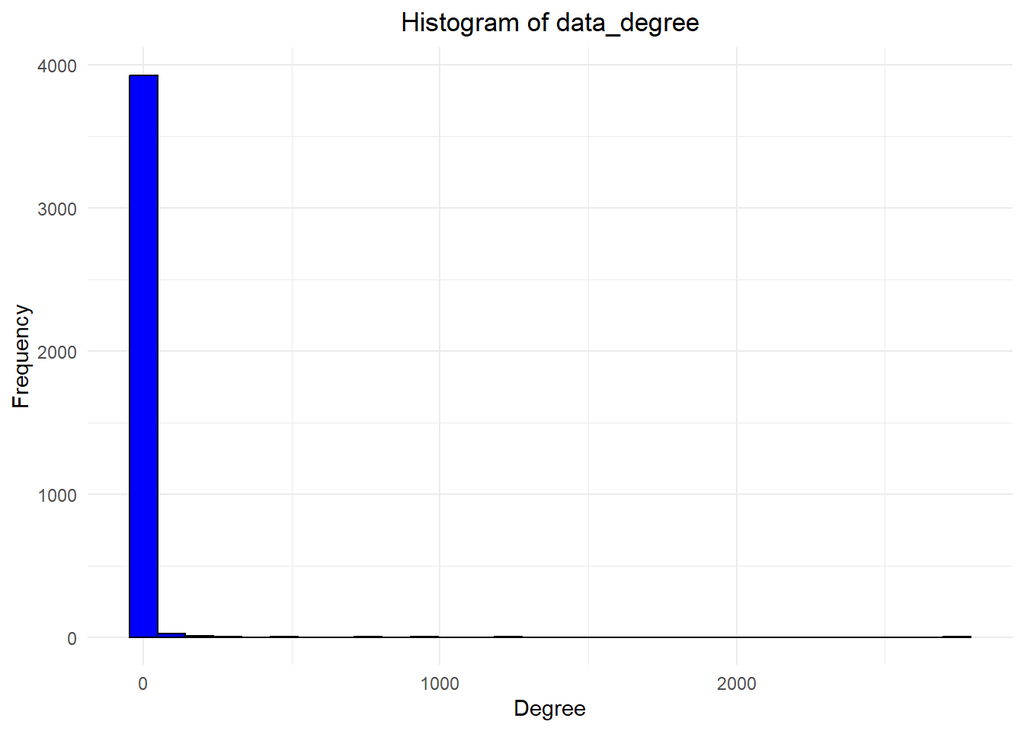

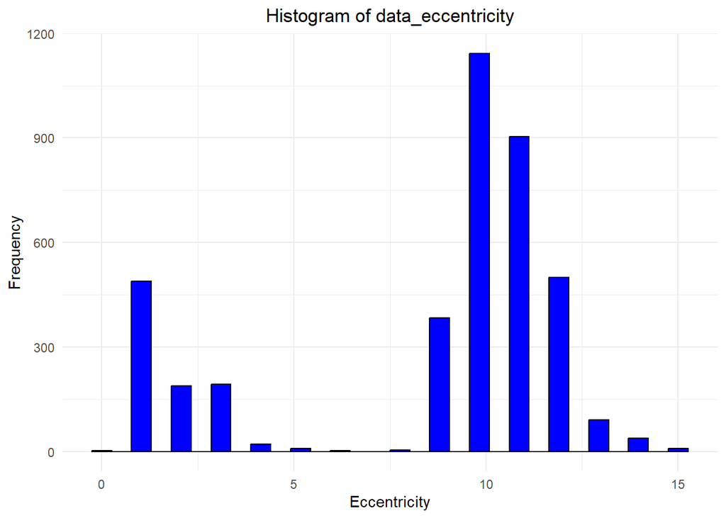

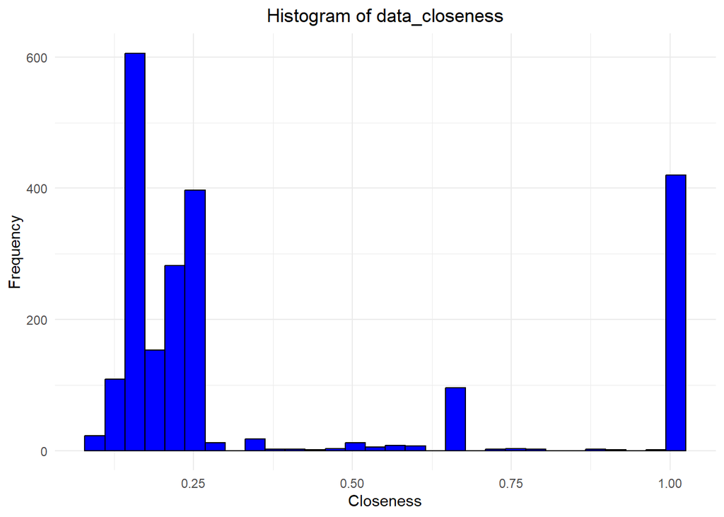

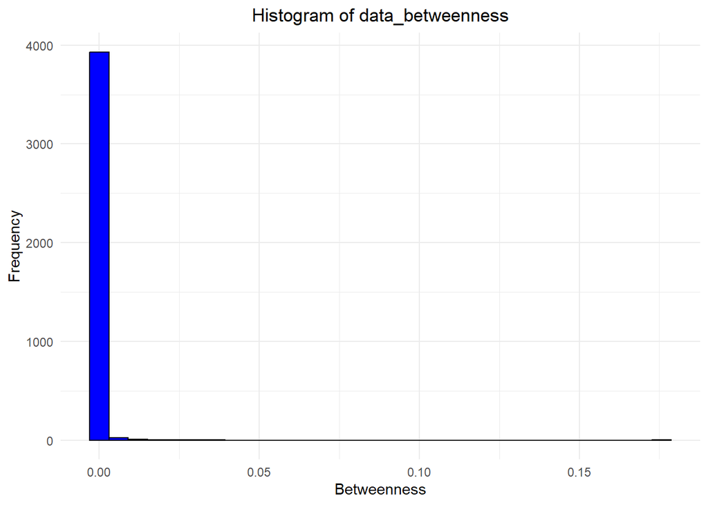

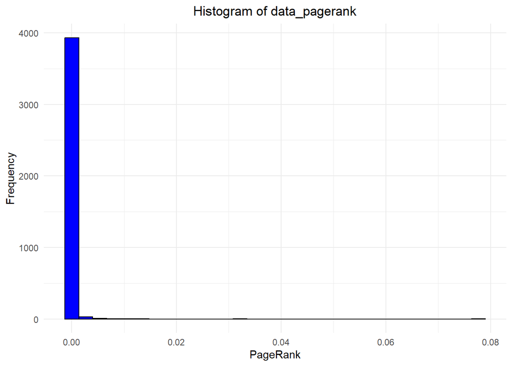

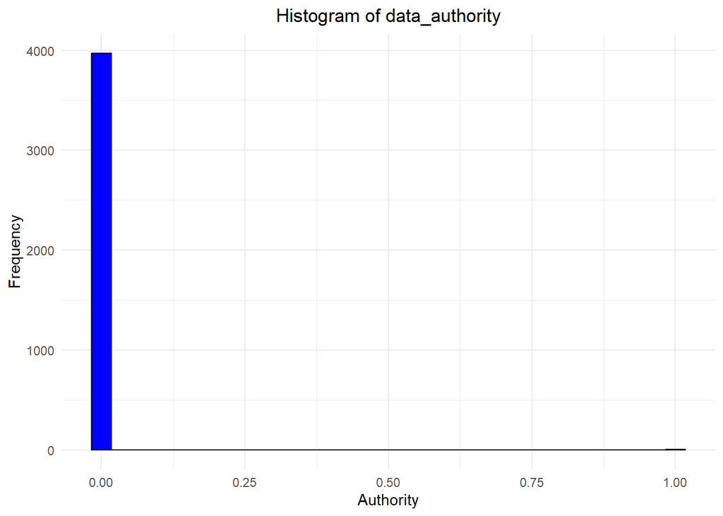

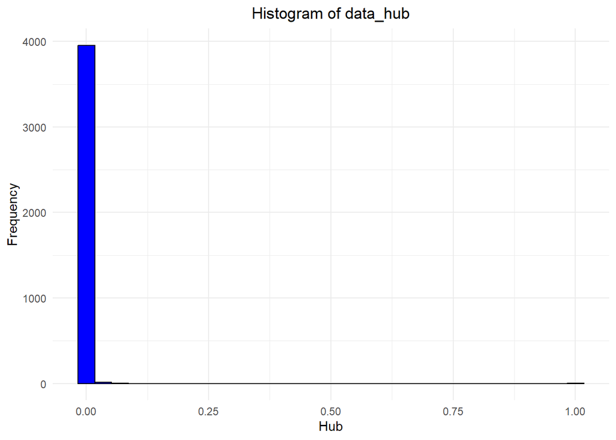

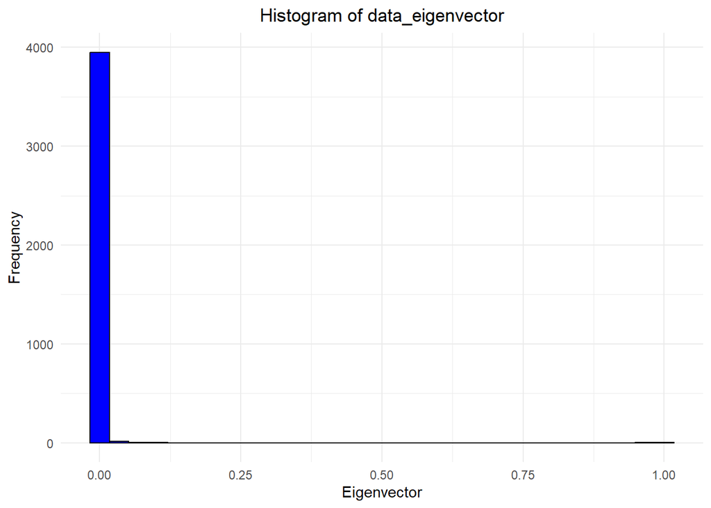

```r
# Ensure each data frame has a correctly named column and convert to numeric
data_list <- list(
  data_degree = data.frame(Degree = as.numeric(degree_centrality)),
  data_eccentricity = data.frame(Eccentricity = as.numeric(eccentricity_centrality)),
  data_closeness = data.frame(Closeness = as.numeric(closeness_centrality)),
  data_betweenness = data.frame(Betweenness = as.numeric(betweenness_centrality)),
  data_pagerank = data.frame(PageRank = as.numeric(pagerank_centrality)),
  data_authority = data.frame(Authority = as.numeric(authority_scores)),
  data_hub = data.frame(Hub = as.numeric(hub_scores)),
  data_eigenvector = data.frame(Eigenvector = as.numeric(eigenvector_centrality))
)

# Function to plot histogram using ggplot2
plot_histogram <- function(data, title) {
  column_name <- names(data)[1]
  p <- ggplot(data, aes_string(x = column_name)) +
    geom_histogram(bins = 30, fill = "blue", color = "black", na.rm = TRUE) +
    theme_minimal() +
    labs(title = title, x = column_name, y = "Frequency") +
    theme(plot.title = element_text(hjust = 0.5))
  print(p)
}

for (name in names(data_list)) {
    plot_histogram(data_list[[name]], paste("Histogram of", name))
  }
```

3.Community Detection In this part, I employ the Walktrap method to detect communities within the Ethereum transaction network, assigning unique IDs and colors to each community to visually distinguish them. After mapping these attributes, I save the enhanced network to a GraphML file for further analysis and visualization in other tools. I also calculate the modularity to assess the strength of the community divisions, providing insights into how nodes cluster together. This method helps reveal the network’s structure, useful for understanding interaction patterns.

```r
# Apply the Walktrap community detection method for directed graphs
community_walktrap <- cluster_walktrap(network)

# Assign community IDs to vertices
V(network)$community_id <- membership(community_walktrap)

# Generate colors for each unique community
communities <- unique(V(network)$community_id)
colors <- rainbow(length(communities))
names(colors) <- communities

# Assign colors to vertices based on their community ID
V(network)$color <- colors[V(network)$community_id]

# Save the network with all attributes to GraphML
write_graph(network, file = "C:/Users/zhouyi/Desktop/new/network10000.graphml", format = "graphml")


# Calculate modularity of the community structure
modularity_value <- modularity(community_walktrap)
cat("Modularity of community structure:", modularity_value, "\n")
```

```
## Modularity of community structure: 0.7403053
```

whole dynamic graph

```r
library(igraph)
# Specify column classes for label datasets
labels_col_types <- c(label = "character", address = "character",
                      name = "character", asset = "character")

# Read the datasets with explicit data type handling
transactions2 <- read.csv("C:/Users/zhouyi/Desktop/new/first_10000.csv",
                         colClasses = transactions_col_types, stringsAsFactors = FALSE)
# Assign artificial timestamps assuming each row represents a consecutive unit of time
transactions$timestamp <- 1:nrow(transactions)

# Create an edge list with timestamps
edge_list <- data.frame(
  from = transactions$from_address,
  to = transactions$to_address,
  start = transactions$timestamp,
  end = transactions$timestamp + 1  # Assuming each transaction lasts for one unit of time
)

# Create a graph from the edge list
graph <- graph_from_data_frame(d = edge_list, directed = TRUE)

# Apply the Walktrap community detection method
community_walktrap <- cluster_walktrap(graph)

# Assign community IDs to vertices
V(graph)$community_id <- membership(community_walktrap)

# Generate colors for each unique community
communities <- unique(V(graph)$community_id)
colors <- rainbow(length(communities))
names(colors) <- communities

# Assign colors to vertices based on their community ID
V(graph)$color <- colors[V(graph)$community_id]

# Set dynamic attributes for edges
E(graph)$start <- edge_list$start
E(graph)$end <- edge_list$end

# Export the graph to GraphML format with dynamic attributes
write_graph(graph, file="C:/Users/zhouyi/Downloads/cpts591/GraphML_Files/dynamic_network.graphml", format="graphml")

# Confirmation message
print("Dynamic network GraphML file has been saved with community color coding.")
```

```
## [1] "Dynamic network GraphML file has been saved with community color coding."
```

node dynamic graph: 0xf20b9e713a33f61fa38792d2afaf1cd30339126a

```r
library(igraph)

# Specify column classes for label datasets
labels_col_types <- c(label = "character", address = "character",
                      name = "character", asset = "character")

# Read the datasets with explicit data type handling
transactions2 <- read.csv("C:/Users/zhouyi/Desktop/new/first_10000.csv",
                         colClasses = transactions_col_types, stringsAsFactors = FALSE)
# Assign artificial timestamps assuming each row represents a consecutive unit of time
transactions2$timestamp <- 1:nrow(transactions2)

# Filter transactions to include only those involving the specific node
specific_node <- "0xf20b9e713a33f61fa38792d2afaf1cd30339126a"
filtered_transactions <- transactions2[
  transactions2$from_address == specific_node | transactions2$to_address == specific_node, ]

# Set a final timestamp that extends beyond the last transaction for permanent visibility
final_timestamp <- max(transactions2$timestamp) + 1

# Create an edge list with timestamps from the filtered transactions
edge_list <- data.frame(
  from = filtered_transactions$from_address,
  to = filtered_transactions$to_address,
  start = filtered_transactions$timestamp,
  end = final_timestamp  # Set end time to a fixed value beyond the last timestamp
)

# Create a graph from the edge list
graph <- graph_from_data_frame(d = edge_list, directed = TRUE)

# Apply the Walktrap community detection method (optional if needed for a small subset)
community_walktrap <- cluster_walktrap(graph)

# Assign community IDs to vertices
V(graph)$community_id <- membership(community_walktrap)

# Generate colors for each unique community
communities <- unique(V(graph)$community_id)
colors <- rainbow(length(communities))
names(colors) <- communities

# Assign colors to vertices based on their community ID
V(graph)$color <- colors[V(graph)$community_id]

# Initialize node appearance times
V(graph)$start <- final_timestamp  # Default to final timestamp

# Update node start times based on the earliest edge connection
for(v in V(graph)) {
  incident_edges <- incident(graph, v)
  earliest_start <- min(E(graph)$start[incident_edges])
  V(graph)$start[v] <- earliest_start
}

# All nodes and edges end at the same final timestamp
V(graph)$end <- final_timestamp
E(graph)$end <- rep(final_timestamp, ecount(graph))

# Export the graph to GraphML format with dynamic attributes
write_graph(graph, file="C:/Users/zhouyi/Downloads/cpts591/GraphML_Files/dynamic_network(0xf20b9e).graphml", format="graphml")

# Confirmation message
print("Dynamic network GraphML file has been saved with dynamic node and permanent edge visibility, focusing on node 0xf20b9e713a33f61fa38792d2afaf1cd30339126a")
```

```
## [1] "Dynamic network GraphML file has been saved with dynamic node and permanent edge visibility, focusing on node 0xf20b9e713a33f61fa38792d2afaf1cd30339126a"
```

node dynamic graph: 0x3f5ce5fbfe3e9af3971dd833d26ba9b5c936f0be

```r
library(igraph)

# Specify column classes for label datasets
labels_col_types <- c(label = "character", address = "character",
                      name = "character", asset = "character")

# Read the datasets with explicit data type handling
transactions2 <- read.csv("C:/Users/zhouyi/Desktop/new/first_10000.csv",
                         colClasses = transactions_col_types, stringsAsFactors = FALSE)
# Assign artificial timestamps assuming each row represents a consecutive unit of time
transactions2$timestamp <- 1:nrow(transactions2)

# Filter transactions to include only those involving the specific node
specific_node <- "0x3f5ce5fbfe3e9af3971dd833d26ba9b5c936f0be"
filtered_transactions2 <- transactions2[
  transactions2$from_address == specific_node | transactions2$to_address == specific_node, ]

# Set a final timestamp that extends beyond the last transaction for permanent visibility
final_timestamp <- max(transactions2$timestamp) + 1

# Create an edge list with timestamps from the filtered transactions
edge_list <- data.frame(
  from = filtered_transactions2$from_address,
  to = filtered_transactions2$to_address,
  start = filtered_transactions2$timestamp,
  end = final_timestamp  # Set end time to a fixed value beyond the last timestamp
)

# Create a graph from the edge list
graph <- graph_from_data_frame(d = edge_list, directed = TRUE)

# Apply the Walktrap community detection method (optional if needed for a small subset)
community_walktrap <- cluster_walktrap(graph)

# Assign community IDs to vertices
V(graph)$community_id <- membership(community_walktrap)

# Generate colors for each unique community
communities <- unique(V(graph)$community_id)
colors <- rainbow(length(communities))
names(colors) <- communities

# Assign colors to vertices based on their community ID
V(graph)$color <- colors[V(graph)$community_id]

# Initialize node appearance times
V(graph)$start <- final_timestamp  # Default to final timestamp

# Update node start times based on the earliest edge connection
for(v in V(graph)) {
  incident_edges <- incident(graph, v)
  earliest_start <- min(E(graph)$start[incident_edges])
  V(graph)$start[v] <- earliest_start
}

# All nodes and edges end at the same final timestamp
V(graph)$end <- final_timestamp
E(graph)$end <- rep(final_timestamp, ecount(graph))

# Export the graph to GraphML format with dynamic attributes
write_graph(graph, file="C:/Users/zhouyi/Downloads/cpts591/GraphML_Files/dynamic_network(0x3f5ce).graphml", format="graphml")

# Confirmation message
print("Dynamic network GraphML file has been saved with dynamic node and permanent edge visibility, focusing on node 0x3f5ce5fbfe3e9af3971dd833d26ba9b5c936f0be")
```

```
## [1] "Dynamic network GraphML file has been saved with dynamic node and permanent edge visibility, focusing on node 0x3f5ce5fbfe3e9af3971dd833d26ba9b5c936f0be"
```

Transaction Volume Over Time Analyze the number and volume of transactions over time to observe any trends or patterns, such as periods of high activity or changes in transaction behavior.(eigenvector centrality)

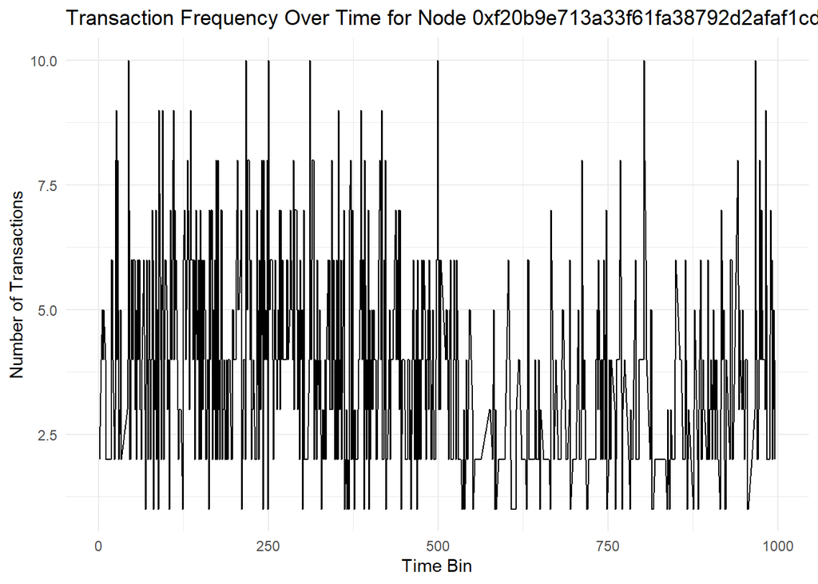

```r
library(ggplot2)

# Assuming 'filtered_transactions' includes a column 'timestamp' representing sequential units of time
# Convert these timestamps to a more aggregated time scale, e.g., by grouping every 10 units together
filtered_transactions$TimeBin <- cut(filtered_transactions$timestamp, breaks = seq(from = min(filtered_transactions$timestamp), to = max(filtered_transactions$timestamp), by = 10),
                                     include.lowest = TRUE, labels = FALSE)

# Aggregate transaction counts by new time bins
transactions_by_time <- aggregate(x = list(TransactionCount = filtered_transactions$timestamp),
                                  by = list(TimeBin = filtered_transactions$TimeBin), FUN = length)

# Plot transaction frequency over time, now using time bins
ggplot(transactions_by_time, aes(x = TimeBin, y = TransactionCount)) +
  geom_line() +
  labs(title = "Transaction Frequency Over Time for Node 0xf20b9e713a33f61fa38792d2afaf1cd30339126a",
       x = "Time Bin", y = "Number of Transactions") +
  theme_minimal()
```

Transaction Amount Analysis If transaction amounts are available, you can plot the total or average transaction amounts over time to detect any fluctuations in the volume of assets being transferred.(eigenvector centrality)

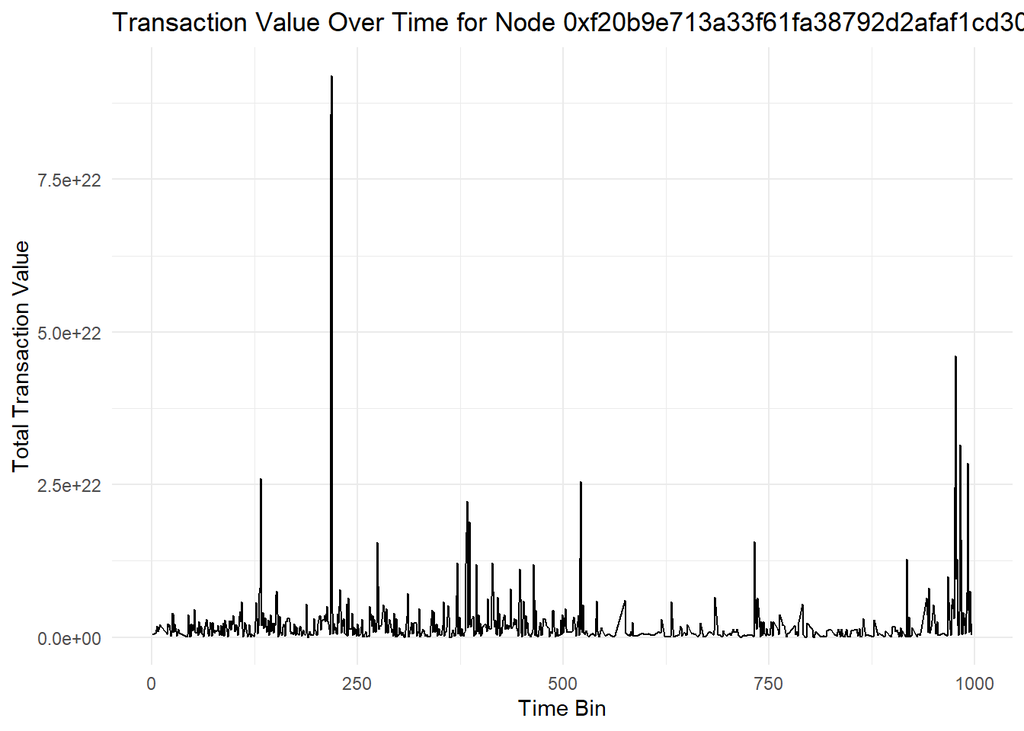

```r
library(ggplot2)

# Assuming 'filtered_transactions' includes a column 'timestamp' representing sequential units of time
# Convert these timestamps to a more aggregated time scale, e.g., by grouping every 10 units together
filtered_transactions$TimeBin <- cut(filtered_transactions$timestamp,
                                     breaks = seq(from = min(filtered_transactions$timestamp),
                                                  to = max(filtered_transactions$timestamp), by = 10),
                                     include.lowest = TRUE, labels = FALSE)

# Aggregate transaction values by new time bins
transactions_by_value <- aggregate(value ~ TimeBin, data=filtered_transactions, FUN = sum)

# Plot transaction values over time, now using time bins
ggplot(transactions_by_value, aes(x = TimeBin, y = value)) +
  geom_line() +
  labs(title = "Transaction Value Over Time for Node 0xf20b9e713a33f61fa38792d2afaf1cd30339126a",
       x = "Time Bin", y = "Total Transaction Value") +
  theme_minimal()
```

Transaction Volume Over Time Analyze the number and volume of transactions over time to observe any trends or patterns, such as periods of high activity or changes in transaction behavior.(page rank centrality)

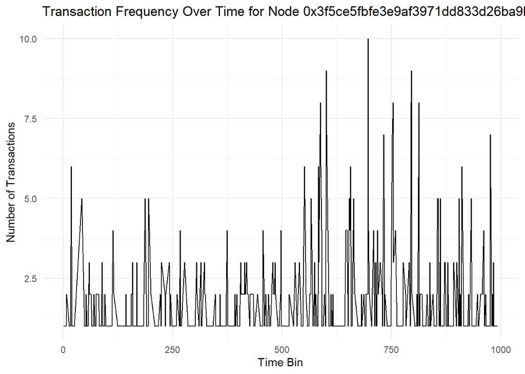

```r
library(ggplot2)

# Assuming 'filtered_transactions' includes a column 'timestamp' representing sequential units of time
# Convert these timestamps to a more aggregated time scale, e.g., by grouping every 10 units together
filtered_transactions2$TimeBin <- cut(filtered_transactions2$timestamp, breaks = seq(from = min(filtered_transactions2$timestamp), to = max(filtered_transactions2$timestamp), by = 10),
                                     include.lowest = TRUE, labels = FALSE)

# Aggregate transaction counts by new time bins
transactions_by_time <- aggregate(x = list(TransactionCount = filtered_transactions2$timestamp),
                                  by = list(TimeBin = filtered_transactions2$TimeBin), FUN = length)

# Plot transaction frequency over time, now using time bins
ggplot(transactions_by_time, aes(x = TimeBin, y = TransactionCount)) +
  geom_line() +
  labs(title = "Transaction Frequency Over Time for Node 0x3f5ce5fbfe3e9af3971dd833d26ba9b5c936f0be",
       x = "Time Bin", y = "Number of Transactions") +
  theme_minimal()
```

Transaction Amount Analysis If transaction amounts are available, you can plot the total or average transaction amounts over time to detect any fluctuations in the volume of assets being transferred.(page rank centrality)

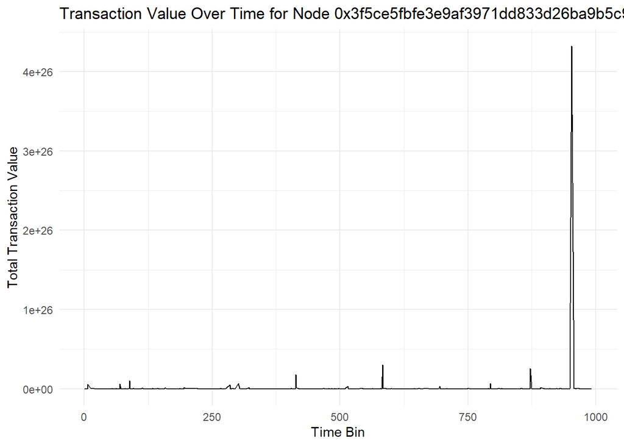

```r
library(ggplot2)

# Assuming 'filtered_transactions' includes a column 'timestamp' representing sequential units of time
# Convert these timestamps to a more aggregated time scale, e.g., by grouping every 10 units together
filtered_transactions2$TimeBin <- cut(filtered_transactions2$timestamp,
                                     breaks = seq(from = min(filtered_transactions2$timestamp),
                                                  to = max(filtered_transactions2$timestamp), by = 10),
                                     include.lowest = TRUE, labels = FALSE)

# Aggregate transaction values by new time bins
transactions_by_value <- aggregate(value ~ TimeBin, data=filtered_transactions2, FUN = sum)

# Plot transaction values over time, now using time bins
ggplot(transactions_by_value, aes(x = TimeBin, y = value)) +
  geom_line() +
  labs(title = "Transaction Value Over Time for Node 0x3f5ce5fbfe3e9af3971dd833d26ba9b5c936f0be",
       x = "Time Bin", y = "Total Transaction Value") +
  theme_minimal()
```

4. Edge Dynamics Study how relationships (edges) form and dissolve over time, providing insights into the stability and dynamics of connections within the network.

```r
# Specify column classes for label datasets
labels_col_types <- c(label = "character", address = "character",
                      name = "character", asset = "character")

# Read the datasets with explicit data type handling
transactions2 <- read.csv("C:/Users/zhouyi/Desktop/new/first_10000.csv",
                         colClasses = transactions_col_types, stringsAsFactors = FALSE)
```

```r
# Assign artificial timestamps assuming each row represents a consecutive unit of time
transactions2$timestamp <- 1:nrow(transactions2)

# Create the dynamic graph
graph <- graph_from_data_frame(transactions2, directed = TRUE)

# Initialize a list to store edge presence
edge_presence <- list()

# Iterate over each timestamp to track edge presence
timestamps <- unique(transactions2$timestamp)
for (t in timestamps) {
    subgraph_t <- subgraph.edges(graph, E(graph)[transactions2$timestamp == t], delete.vertices = FALSE)
    edge_presence[[as.character(t)]] <- get.edgelist(subgraph_t)
}

# Compare edge lists between consecutive timestamps to identify formation and dissolution
edge_changes <- list()

for (i in 1:(length(edge_presence) - 1)) {
    edges_present <- edge_presence[[i]]
    edges_next <- edge_presence[[i + 1]]

    # Convert edge lists to character for easy comparison
    edges_present_char <- apply(edges_present, 1, paste, collapse = "-")
    edges_next_char <- apply(edges_next, 1, paste, collapse = "-")

    # Find edges that form and dissolve
    formed_edges <- setdiff(edges_next_char, edges_present_char)
    dissolved_edges <- setdiff(edges_present_char, edges_next_char)

    edge_changes[[i]] <- list(formed = formed_edges, dissolved = dissolved_edges)
}

# Debug output
print("Sample of formed edges:")
```

```
## [1] "Sample of formed edges:"
```

```r
print(edge_changes[[1]]$formed)
```

```
## character(0)
```

```r
print("Sample of dissolved edges:")
```

```
## [1] "Sample of dissolved edges:"
```

```r
print(edge_changes[[1]]$dissolved)
```

```
## character(0)
```

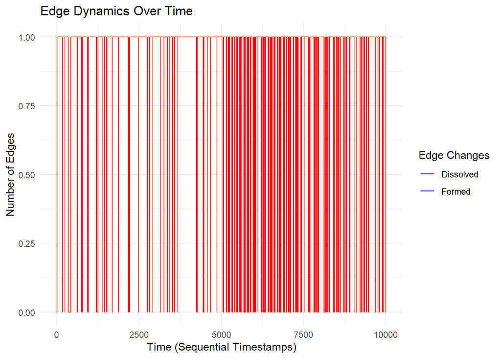

```r
# Example to plot the number of formed and dissolved edges over time
formed_counts <- sapply(edge_changes, function(x) length(x$formed))
dissolved_counts <- sapply(edge_changes, function(x) length(x$dissolved))

df_changes <- data.frame(Time = 1:(length(timestamps) - 1), Formed = formed_counts, Dissolved = dissolved_counts)

ggplot(df_changes, aes(x = Time)) +
    geom_line(aes(y = Formed, colour = "Formed")) +
    geom_line(aes(y = Dissolved, colour = "Dissolved")) +
    labs(title = "Edge Dynamics Over Time", x = "Time (Sequential Timestamps)", y = "Number of Edges") +
    scale_colour_manual(name = "Edge Changes", values = c("Formed" = "blue", "Dissolved" = "red")) +
    theme_minimal()
```

4.Network Motifs and Subgraph Analysis In this part, I define and analyze ten different directed motifs in the Ethereum transaction network to uncover complex interaction patterns. I calculate the occurrences of motifs like “Triangle,” “Star,” and “M-Shape,” using them to highlight prevalent transaction structures. After quantifying these, I visually represent each motif in a grid and provide detailed descriptions to elucidate their roles within the network.

```
##              Motif_ID Frequency
## triangle     triangle       477
## star             star  75659880
## divergent   divergent       252
## in_chain     in_chain    126408
## bidir_edge bidir_edge       522
## out_fan       out_fan    338984
## in_fan         in_fan    186878
## m_shape       m_shape 386272452
## all_to_one all_to_one  62793072
## t_shape       t_shape  51228960
```

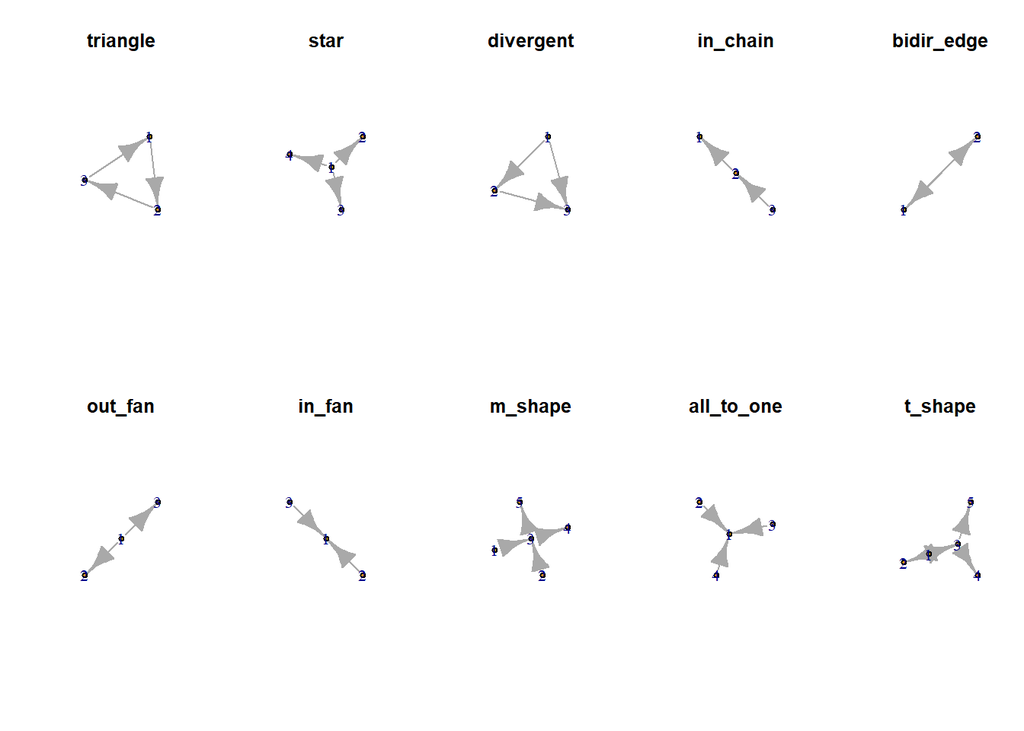

[output not shown]

```r
suppressWarnings({
# Define 10 specific directed 3-node motifs with new replacements
motifs <- list(
  triangle = graph_from_edgelist(matrix(c(1,2, 2,3, 3,1), ncol=2, byrow=TRUE), directed=TRUE),
  star = graph_from_edgelist(matrix(c(1,2, 1,3, 1,4), ncol=2, byrow=TRUE), directed=TRUE),
  divergent = graph_from_edgelist(matrix(c(1,2, 1,3, 2,3), ncol=2, byrow=TRUE), directed=TRUE),
  in_chain = graph_from_edgelist(matrix(c(2,1, 3,2), ncol=2, byrow=TRUE), directed=TRUE),
  bidir_edge = graph_from_edgelist(matrix(c(1,2, 2,1), ncol=2, byrow=TRUE), directed=TRUE),
  out_fan = graph_from_edgelist(matrix(c(1,2, 1,3), ncol=2, byrow=TRUE), directed=TRUE),
  in_fan = graph_from_edgelist(matrix(c(2,1, 3,1), ncol=2, byrow=TRUE), directed=TRUE),
  m_shape = graph_from_edgelist(matrix(c(1,3, 2,3, 3,4, 3,5), ncol=2, byrow=TRUE), directed=TRUE),
  all_to_one = graph_from_edgelist(matrix(c(2,1, 3,1, 4,1), ncol=2, byrow=TRUE), directed=TRUE),
  t_shape = graph_from_edgelist(matrix(c(1,2, 1,3, 3,4, 3,5), ncol=2, byrow=TRUE), directed=TRUE)
)

# Count the specified motifs in the directed network
motif_counts <- sapply(motifs, function(m) {
  graph.count.subisomorphisms.vf2(network, m)
})


# Create a data frame for the motif counts
motif_count_df <- data.frame(
  Motif_ID = names(motif_counts),
  Frequency = motif_counts
)

# Print the motif counts
print(motif_count_df)

# Visualize the specific motifs
par(mfrow=c(2, 5))  # Set up plot area to display 10 plots in a 2x5 grid
plot_names <- names(motifs)
for (i in seq_along(motifs)) {
  plot(motifs[[i]], main=plot_names[i])
}

# Print detailed descriptions of each motif type
cat("Detailed descriptions of each directed motif type in the Ethereum DEX network:\n")
descriptions <- c(
  "Triangle: A directed loop where each node transfers to the next, possibly indicating cyclical trading.",
  "Star: A central node with directed edges to multiple others, indicating a hub in the network.",
  "Divergent: A node directs to two others, which also have a connection, forming a V shape.",
  "In Chain: A sequence of nodes where each node is directed from the previous, forming a chain.",
  "Bidirectional Edge: Two nodes with edges in both directions, indicating mutual interaction.",
  "Out Fan: A single node with outgoing edges to several nodes, like a broadcaster.",
  "In Fan: A single node with incoming edges from several nodes, like a collector.",
  "T-Shape: A central node connected to two distinct pairs of nodes, forming a T shape in the interaction.",
  "All to One: All nodes in the motif direct to a single node, like a sink.",
  "M-Shape: A central node with two incoming edges and two outgoing edges to different nodes, forming an M shape."
)
for (i in seq_along(descriptions)) {
  cat(sprintf("%s: %s\n", plot_names[i], descriptions[i]))
}
})
```

5.Influence analysis In this part, I compute Eigenvector centrality to identify the most influential nodes in the Ethereum transaction network, and I pinpoint the top five. Using the most influential node, I simulate information diffusion, demonstrating how influence spreads through the network. This simulation is visualized by marking active nodes in red, providing insights into the impact of key nodes on the network’s dynamics.

```r
# Calculate Eigenvector centrality for each node
eigenvector_centrality <- eigen_centrality(network)$vector

# Identify top 5 influential nodes based on Eigenvector centrality
top_influential_nodes <- order(eigenvector_centrality, decreasing = TRUE)[1:5]

# Print top influential nodes
cat("Top 5 influential nodes based on Eigenvector Centrality:", top_influential_nodes, "\n")
```

```
## Top 5 influential nodes based on Eigenvector Centrality: 4 3 144 175 634
```

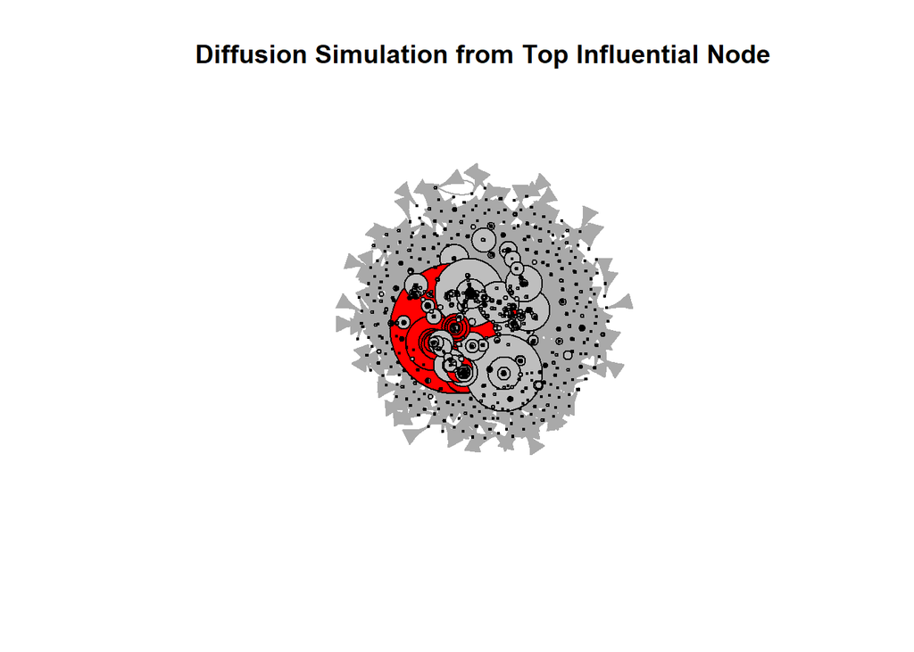

```r
# Function to simulate information diffusion
simulate_diffusion <- function(network, initial_nodes, prob = 0.05, steps = 10) {
  active <- rep(FALSE, vcount(network))
  active[initial_nodes] <- TRUE
  newly_active <- initial_nodes

  for (step in 1:steps) {
    if (length(newly_active) == 0) break
    current_active <- newly_active
    newly_active <- c()

    for (node in current_active) {
      neighbors <- neighbors(network, node)
      for (neighbor in neighbors) {
        if (!active[neighbor]) {
          if (runif(1) < prob) {
            newly_active <- c(newly_active, neighbor)
            active[neighbor] <- TRUE
          }
        }
      }
    }
  }

  return(which(active))
}

# Simulate diffusion starting from the most influential node
influential_spread <- simulate_diffusion(network, initial_nodes = top_influential_nodes[1])

# Visualize the result
plot(network, vertex.color = ifelse(1:vcount(network) %in% influential_spread, "red", "gray"),
     vertex.size = sqrt(degree(network)) * 2, vertex.label = NA,
     main = "Diffusion Simulation from Top Influential Node")
```